# BIOF Final Project

Nicholas Giordano

5/21/2019

##Objective Identify if there is an association between early pain management in the battlefield and long-term average pain scores after combat injury

##Describe the sample The dataset includes:

1. **ID** = study number
2. **Pain** = Pain scores, 0 to 10 higher scores indiciate greater pain
3. **Intervention** = Early pain management via regional anesthesia (RA) or no early pain management (No Early RA)
4. **Month** = Month since injury that pain score was documented
5. **LOS** = Length of stay in days at inital hospital as an indiciator of severity of injury
6. **Injury** = Injury Severiy Score, 0 to 75 higher scores indiciate greater injury severity
7. **Observations** = # of observations in the study per subject

```
##        ID            Pain            Intervention      Month
##  Min.   :1002   Min.   :0.000   Early RA   : 794   Min.   : 1.00
##  1st Qu.:1190   1st Qu.:1.000   No Early RA:1409   1st Qu.: 4.00
##  Median :1364   Median :2.000                      Median : 8.00
##  Mean   :1369   Mean   :2.347                      Mean   :10.14
##  3rd Qu.:1538   3rd Qu.:4.000                      3rd Qu.:16.00
##  Max.   :1790   Max.   :9.000                      Max.   :24.00
##       LOS             Injury       observations
##  Min.   :  2.00   Min.   : 1.00   Min.   : 1.000
##  1st Qu.: 12.00   1st Qu.:10.00   1st Qu.: 6.000
##  Median : 25.00   Median :17.00   Median : 8.000
##  Mean   : 34.67   Mean   :17.72   Mean   : 7.602
##  3rd Qu.: 46.00   3rd Qu.:24.00   3rd Qu.:10.000
##  Max.   :234.00   Max.   :54.00   Max.   :12.000
```

###Sample Described by Intervention Group *Individuals with early pain management have slighly lower pain scores*

```
##                           Stratified by Intervention
##                            Early RA      No Early RA   p      test
##   n                          794          1409
##   Pain (mean (SD))          2.15 (1.77)   2.46 (1.95)  <0.001
##   Month (mean (SD))        10.18 (6.60)  10.12 (6.84)   0.838
##   LOS (mean (SD))          40.61 (30.34) 31.32 (31.54) <0.001
##   Injury (mean (SD))       17.00 (8.04)  18.12 (11.25)  0.013
##   observations (mean (SD))  7.76 (2.85)   7.51 (2.58)   0.034
```

##Plot Average Pain Scores over Time There is no clear difference in pain scores by individuals who did and did not receive early pain management over time. Need to adjust for other factors to see if the difference observed in the table above is meaningful or not.

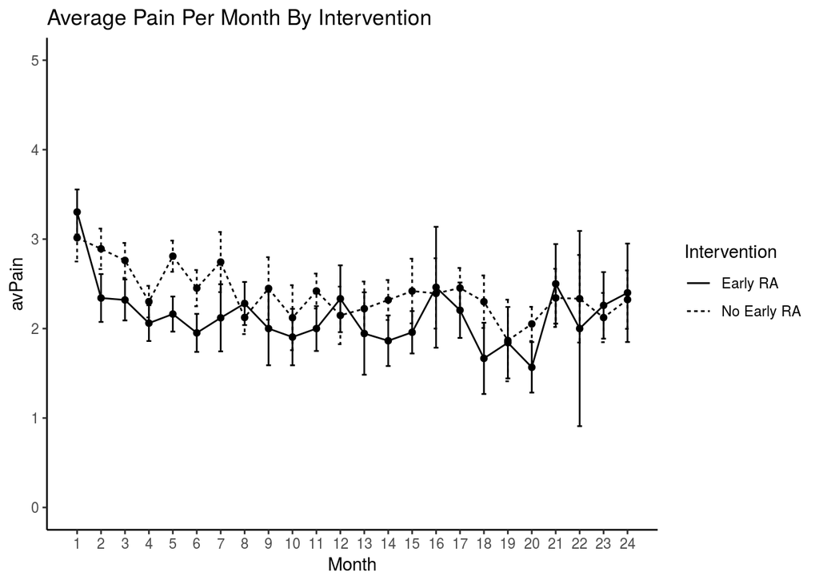

##Adjusted model When we adjust for clinical factors, such as length of stay and injury severity, on average early pain management is associated with lower pain scores over time

[output not shown]

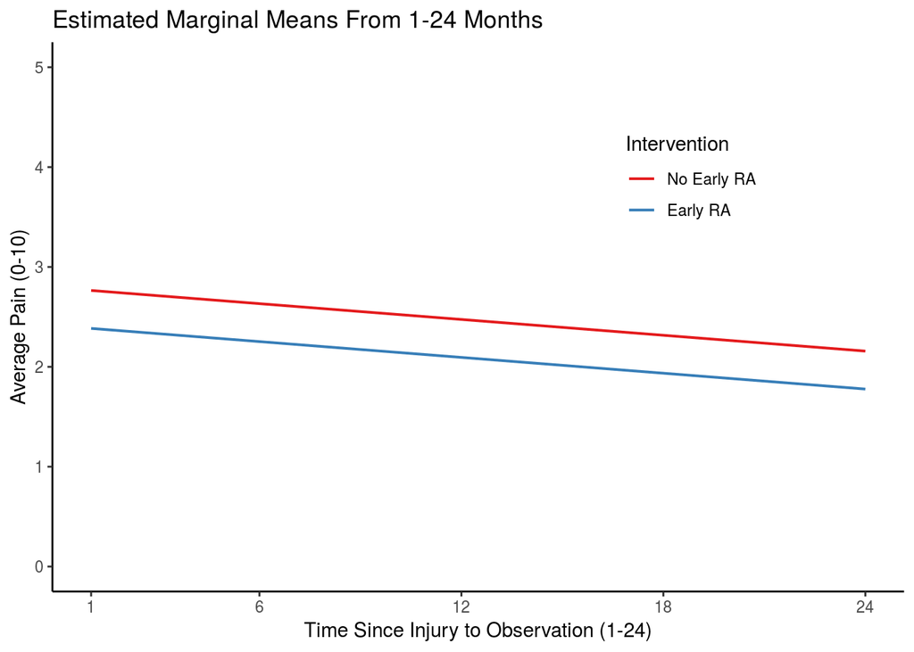